# Food. What works? What doesn’t?

2023-11-11

# Hunger in the United States

Food insecurity is one way we can measure the risk of hunger. It is a federal measurement, the measures the ability of a household’s to provide enough food for every person in the household to have an active, healthy life. In the United States:

- More than 44 million people in the US face hunger
- 13 million children are food insecure (1 in 5)
- 49 million people turned to food assistance for extra help (just in 2022)
- People experience food insecurity in every community.
- Hunger doesn’t affect everyone equally - some groups like children, seniors, and people of color face hunger at much higher rates

“Many people who are facing hunger are forced to make tough choices between paying for food and medical bills, food and rent and/or food and transportation.” - Feeding America

# Food and Welfare Programs (2022)

In 2022 the population for the United States was 338,289,857 individuals. Out of those individualizes millions experienced hunger and food insecurity. Out of the entire population 13% experience hunger, 12.1% were receiving Snap benefits, and 1.8% were on Wic.

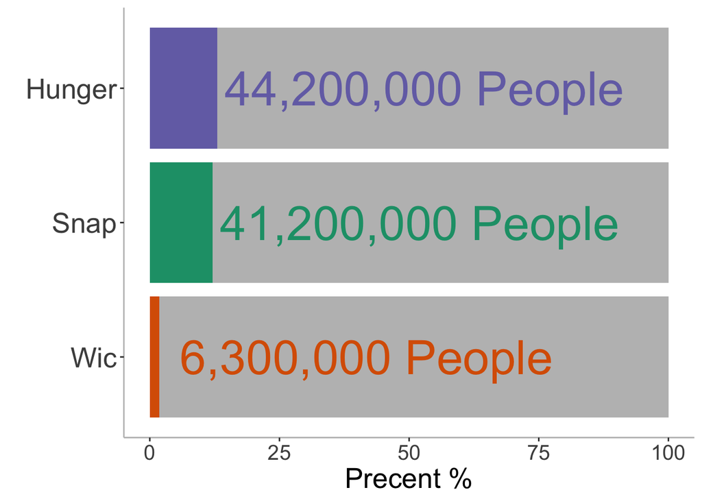

# Participation and Funding for Supplemental Nutrition Assistance Program (SNAP)

SNAP is is a federal program that provides monthly funds for people to buy food. The goal of SNAP is to reduce poverty and food insecurity while stimulating economic growth. SNAP benefits work similar to a debit card where funds are placed on an Electronic Benefit Transfer (EBT) card. Funds are automatically loaded into an account each month and the card can be used to purchase groceries at authorized locations (i.e. grocery stores, Walmart, farmers markets).

SNAP is one of the largest program fighting food insecurity in the United States. Overtime the amount of people who qualify and receive SNAP benefits changes. As the amount of people needing these benefits changes so does the amount of funding.

## Snap Participants

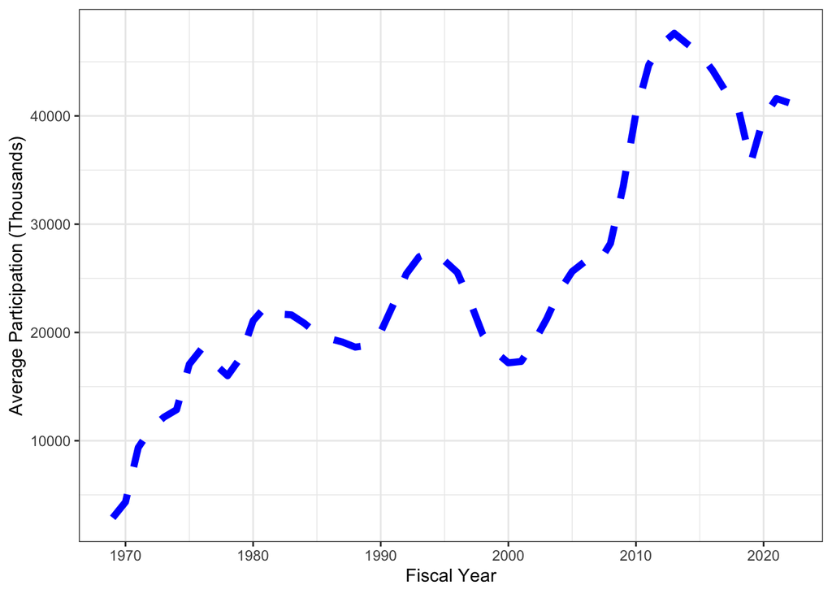

## Snap Funding

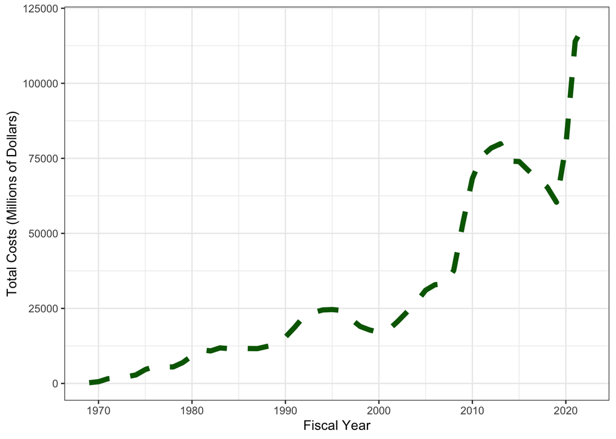

# Are more people reaching out for help as the cost of living goes up?

There are many reasons that the amount of people applying to are receiving SNAP benefits is increasing. Lets see how the price of items consumers are spending there money on has changed. To view this price change we will be using the The Consumer Price Index (CPI). CPI is a measure of the average change over time in the prices paid by urban consumers.

## Food

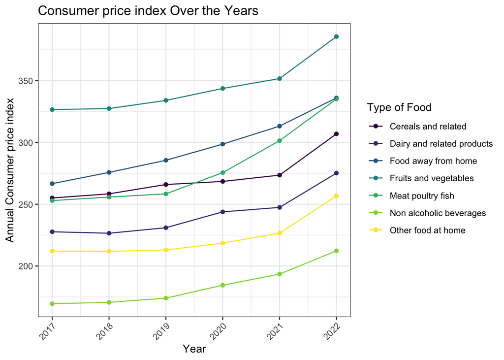

## Other

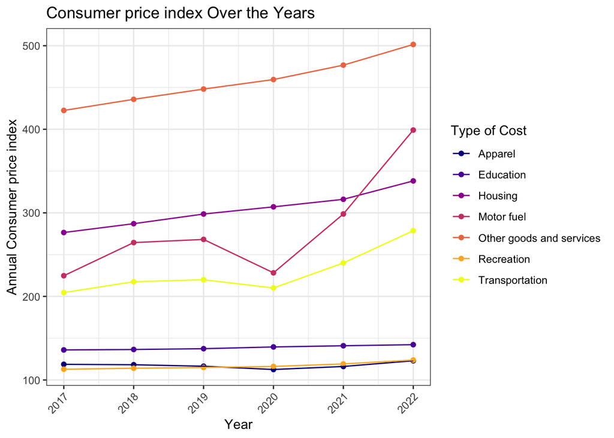

# Inflation

We can also observe how these values change by calculating the inflation!

## Food Inflation

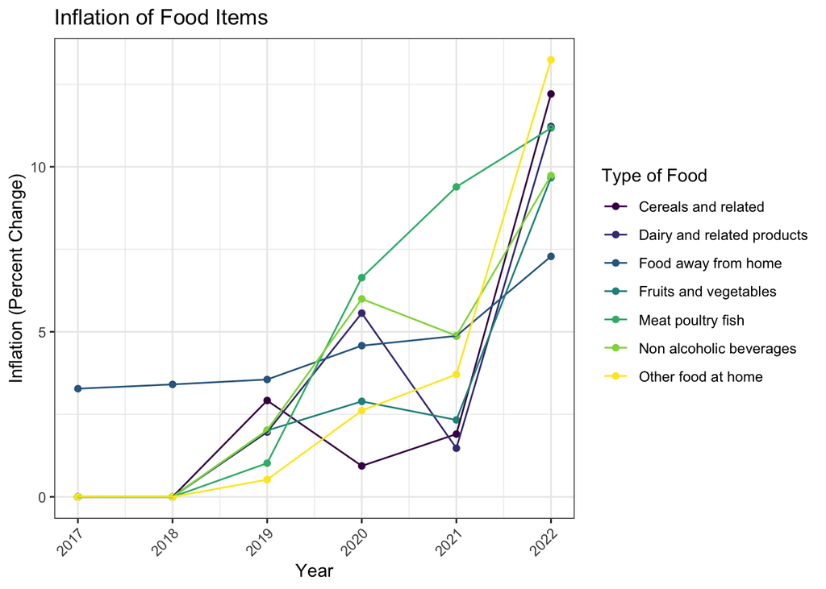

## Other Inflation

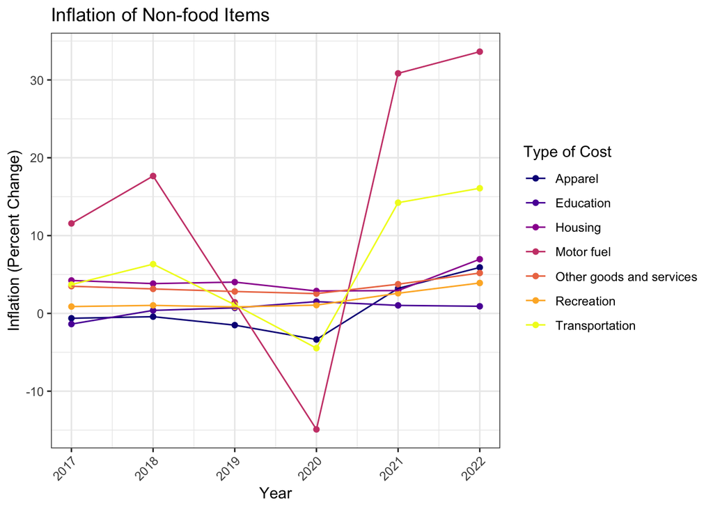

# How is the Hunger Problem in Eugene?

Hunger is experienced in all counties of all states within the US. Let’s look at some Eugene specific data like the population size, number of employees, and individuals that have been served at food distribution centers.

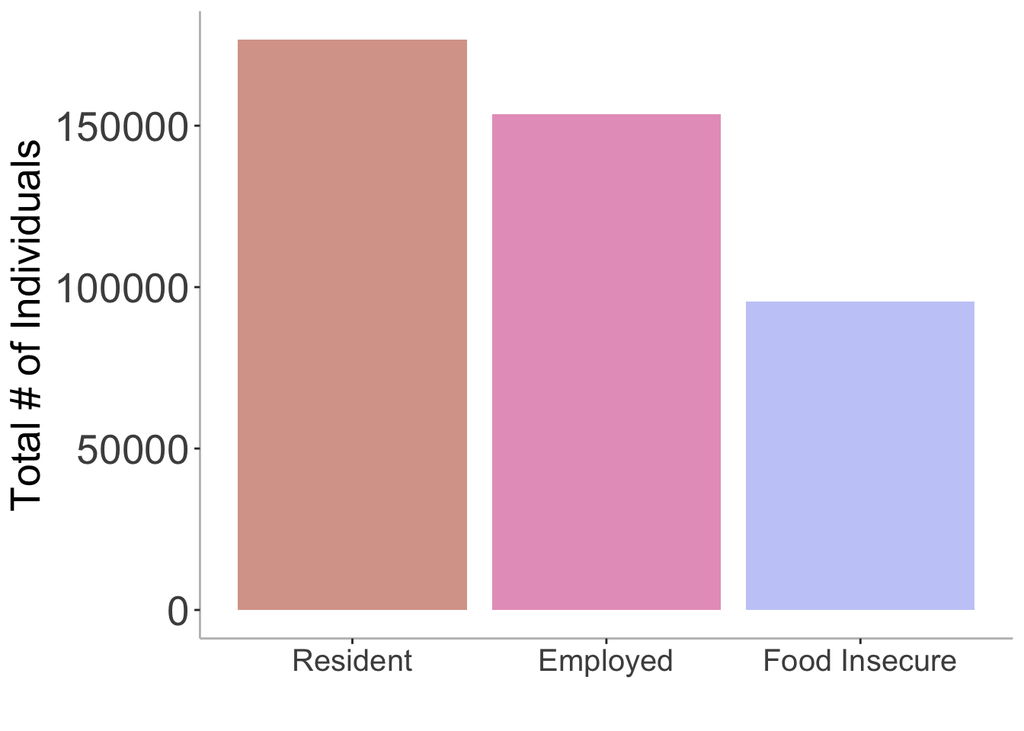

In Eugene Oregon a livable wage is determined to be $36,312 (before taxes) for one adult with no dependents.

## Income Across All Jobs

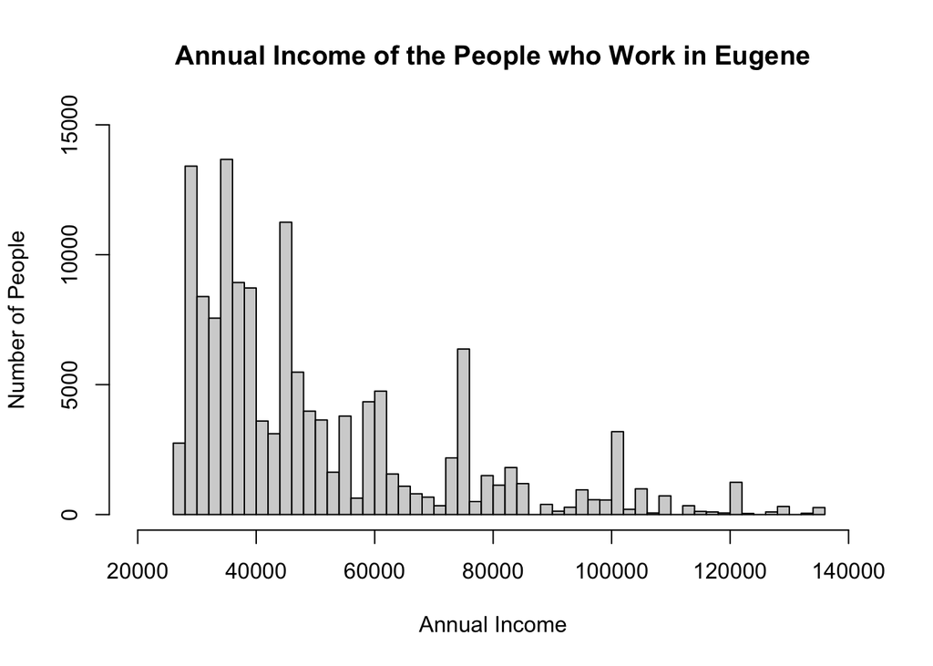

## Receving SNAP & Livable Wage

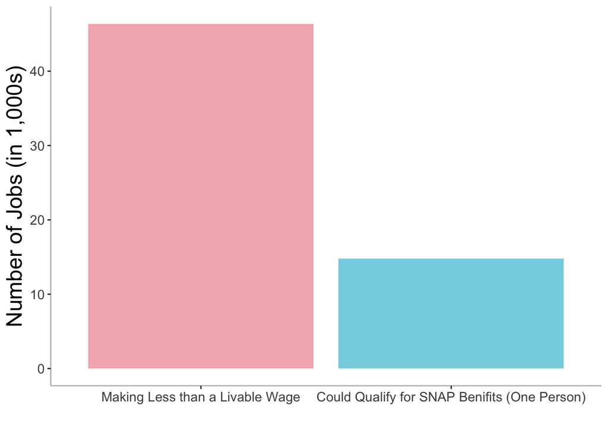

There are many jobs that do not proved a living wage in Eugene OR. Most of these jobs are classified as Fast Food and Counter Workers, Cashiers, and Waiters and Waitresses.

# Orginizations that Serve

In Eugene OR there are 92 organizations that contribute to fighting food insecurity. Below we see how much food is distributed and their locations. The food Insecurity index is a measurement that indicates need (higher score = more need).

## Distributed food

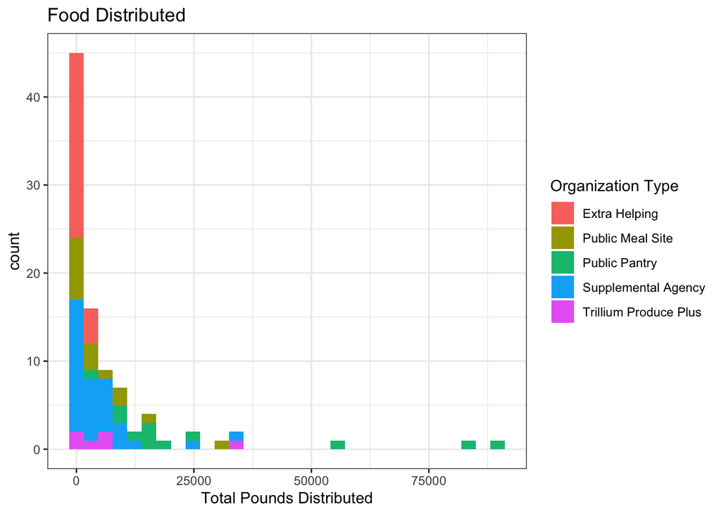

## Locations

[figure not shown]

# Summary

Huger and food insecurity effect many people every year, including people from our community. Food insecurity may be caused by a combination of the contentious increase of essential expenditures (food, housing, transportation). Eugene has done a good job proving places that reduce food insecurity. But on the other hand Eugene OR contains many jobs that cannot reach the minimum amount of pay to obtain a livable wage.

# The Data:

[Hunger facts (Feeding America)](https://www.feedingamerica.org/hunger-in-america#:~:text=More%20than%2044%20million%20people,together%2C%20we%20can%20solve%20it.)

[Hunger and Poverty in America](https://frac.org/hunger-poverty-america#:~:text=Hunger%20Quick%20Facts%20for%202022,Americans%20lived%20in%20these%20households.)

[Snap Information](https://fns-prod.azureedge.us/pd/supplemental-nutrition-assistance-program-snap)

[Wic Information](https://www.ers.usda.gov/topics/food-nutrition-assistance/wic-program/)

[Eugene Population (2020 census and implemented with the use of tidycensus)](https://carolinademography.cpc.unc.edu/2022/05/16/story-recipe-how-to-obtain-census-data-using-r-tidycensus/)

[US population](https://www.census.gov/newsroom/press-releases/2022/2022-population-estimates.html#:~:text=DEC.,components%20of%20change%20released%20today.)

Eugene Employment: From data provided

Eugene Food Insecurity: From data provided

The Consumer Price Index: From data provided

[Maps: Generated by Google maps](https://cran.r-project.org/web/packages/ggmap/index.html)

[Eugene Living Wage](https://livingwage.mit.edu/counties/41039)